# Analysis of 3 time periods: 2000-2006; 2006-2014 and 2014 to Present

There are three types of clearance data on the PARIVESH portal, hosted by the MOEF&CC. These include: Environmental, Forests and Wildlife. The data for Forests and Wildlife are quantifiable, although the data for Wildlife was not available as an excel file and this information had to be scraped from their website.

All analysis being performed is through the R programming environment. Please feel free to edit and use this code as you please. The data used for this purpose is available through the ‘Data’ folder.

```r
# Load required libraries
library(dplyr)
library(ggplot2)
library(RColorBrewer)
library(readxl)
library(lubridate)
```

First, we will carry out some exploratory data analysis using the Forest clearance data. The data available has been stored in 5 separate excel files:

1. All data prior to 2014
2. Data after 2014 is subdivided into:
   1. Allocation of fresh forest land (Form-A)
   2. Application Under Section 2(iii)
   3. Renewal of lease (Form-B)
   4. Prospecting of Minerals (Form-C)

Let’s first analyze data as binned under 3 time periods:

1. 2000 to 2006: Prior to the 2006 amendment of the EIA
2. 2006 to 2014: After the 2006 amendment of the EIA
3. 2014 to Present: An artifical divide as mentioned by the MOEF&CC

```r
names(dat1); names(dat2); names(dat3); names(dat4)
```

```
[1] "state_name"            "Proposal_Name"         "category"
[4] "area_applied"          "date_from_ua_to_nodal" "proposal_status"
[1] "state_name"            "Proposal_Name"         "category"
[4] "area_applied"          "date_from_ua_to_nodal" "proposal_status"
[1] "State_Name"            "Proposal_Name"         "category"
[4] "area_applied"          "date_from_ua_to_nodal" "proposal_status"
[1] "State_Name"            "Proposal_Name"         "category"
[4] "area_applied"          "date_from_ua_to_nodal" "proposal_status"
```

Subsetting the data

Summary of number of grants approved and rejected across these time periods

Between 2000 and 2006, 5076 proposals were categorized as approved / under one of the pending categories. During the same period, 1213 proposals were rejected. Rejection Rate: 19.3%

Between 2007 and 2014, 9829 proposals were categorized as approved / under one of the pending categories. During the same period, 1161 proposals were rejected. Rejection rate: 10.5%

Between 2014 and 2020, 17037 proposals were categorized as approved / under one of the pending categories. During the same period, 120 proposals were rejected. Rejection rate: 0.7%!

```r
n_appro <- dat_2000_2006 %>% select(PROPOSAL_STATUS,AREA_APPLIED) %>%
  group_by(PROPOSAL_STATUS, AREA_APPLIED) %>% summarise() %>% tally(n)
```

```
Error in sum(~n, na.rm = TRUE) : invalid 'type' (closure) of argument
```

Forest area in hectares stated to be cleared / categorized as pending approval

2000 to 2006: Area stated to be cleared / potentially cleared - 6,29,638 hectares 2000 to 2006: Area saved - 2,54,555.6 hectares

2014 to Present: Area stated to be cleared / potentially cleared - 14,82,247 hectares 2014 to Present: Area saved - 13077.03 hectares

| n |
| --- |
| 493242.6 |

Let’s subset only those proposals that were approved.

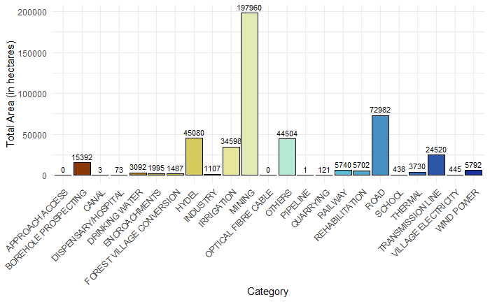

Year and area

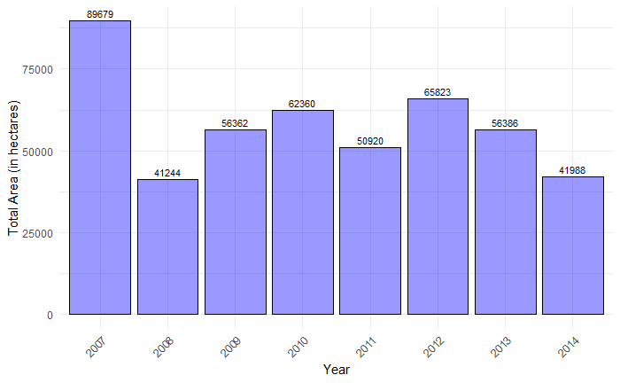

Area and state

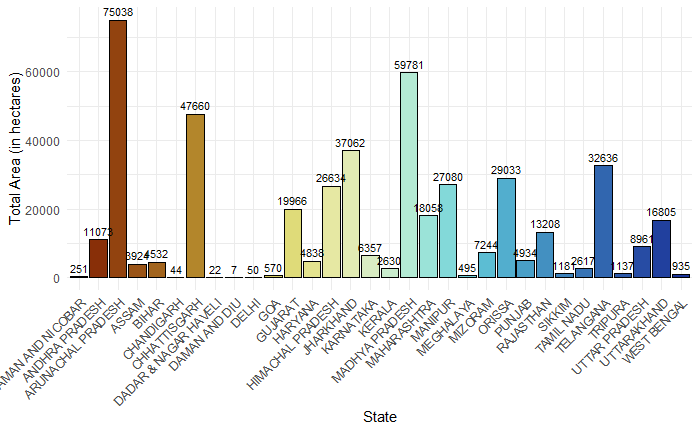